# Homework #4

Ethan Ashby

We will need the following libraries for this homework.

```r
library(tidyverse)
library(readxl)
library(knitr)
```

The following ensures that the same random choices are made each time the document is knit.

```r
set.seed(12345)
```

Instructions:

1. Be sure to put the file `homework-style.css` in the parent directory of the directory where you have your .Rmd file.
2. Put your solutions between the lines that read `:::: {.solution}` and `::::`.
3. Knit the file to .html.
4. Print the file to .pdf using a browser.
5. Upload your .pdf file to Gradescope.
6. After you upload to Gradescope, you will be asked to mark the pages your problem solutions are on.
7. Be sure to box your answers with the `\boxed{put in box}` $\LaTeX$ command.
8. Be sure to give nonintegral answers to four significant digits, except when the form is $a \pm b$. In that case, give $b$ to two significant digits (rounded up) and give $a$ to the same number of *decimal places* as $b$ has.

A sampling of the entering class of a magnet high school shows that 23 are going to enter the Arts track, 32 are going to enter the Science track, and 28 are going to enter the Literature track.

The null hypothesis is that the number of students entering each track is $(X_1, X_2, X_3) \sim \textsf{Multinomial}(83, 1 / 3, 1 / 3, 1 / 3).$

1. If this null hypothesis is true, what is the distribution of $X_1$?
2. What is the distribution of $[X_2 \mid X_1]$?
1. If the null hypothesis is true, $\boxed{X_1 \sim \textsf{Bin}(83, 1/3)}$.
2. Under the null hypothesis, $\boxed{[X_2 \mid X_1] \sim \textsf{Bin}(83-X_1, 1/2)}$

Continuing the last problem. A statistic that can be used to test the null hypothesis that students are entering tracks uniformly at random is
$$S(X_1, X_2, X_3) = \sum_{i = 1}^3 (X_i - (23 + 32 + 28) / 3)^2.$$

The $p$-value is
$$\mathbb{P}(S(X_1, X_2, X_3) \geq S(23, 32, 28)).$$

Estimate the $p$-value with $10^5$ samples from the multinomial distribution. Report your answer as $a \pm b$.

```r
#initialize function that can draw from multinomial distribution
rmultinomial<-function(n,p){
  k<-length(p)
  x<-rep(0, k)
  pnorm<-1
  for(i in 1:k){
    x[i]<-rbinom(1, n, p[i]/pnorm)
    n<-n-x[i]
    pnorm<-pnorm-p[i]
  }
  return(x)
}

#initialize function that can calculate test statistics
test_stat<-function(data, p){sum((data-mean(data))^2)}

####
#simulate under null to obtain p-value
####
#multinomial probabilities under null
set.seed(12345)
p<-c(1,1,1)/3

#calculate our test stat
sdata<-test_stat(data=c(23,32,28), p=p)

#null replicates
res<-replicate(10^5, (test_stat(data=rmultinomial(83, p=p), p=p)))

tibble(
  est_mean=mean(res>=sdata),
  est_error=sd(res>=sdata)/sqrt(length(res))
)
```

```
## # A tibble: 1 x 2
##   est_mean est_error
##      <dbl>     <dbl>
## 1    0.505   0.00158
```

The p-value is $\boxed{0.5050 \pm 0.0016}$.

Suppose $U_1 \sim \textsf{Beta}(3, 1)$ and $[U_2 \mid U_1] \sim \textsf{Unif}([0, U_1])$.

1. Write R code to generate from $(U_1, U_2)$.
2. Estimate $\mathbb{E}[U_2]$ using $10^5$ samples and Basic Monte Carlo. Report your answer as $a \pm b$.

```r
#this function generates random draws from the distribution outlined above
r_u1_u2<-function(){
  #draw from appropriate beta distribution
  U1<-rbeta(1, shape1=3, shape2=1)
  #draw from random uniform distribution with min=0 and max-U1
  U2<-runif(1, min=0, max=U1)
  #return (U1, U2)
  return(c(U1, U2))
}
```

```r
set.seed(12345)
#replicate many times, only returning the second entry (U2)
res<-replicate(10^5, r_u1_u2()[2])

#output in tibble
tibble(
  est_mean=mean(res),
  est_error=sd(res)/sqrt(length(res))
)
```

```
## # A tibble: 1 x 2
##   est_mean est_error
##      <dbl>     <dbl>
## 1    0.375  0.000770
```

The basic Monte Carlo estimate is $\mathbb{E}[U_2]=\boxed{0.37500 \pm 0.00077}$

Consider the Ising model on a 4 by 4 lattice, where the probability of a configuration $x \in \{0, 1\}^{16}$ is proportional to $\exp(-\beta h(x))$, where $h(x)$ counts the number of adjacent (up-down or right-left) nodes that are of equal value in the configuration.

1. Using Acceptance Rejection draw 1000 replications of the model at $\beta = 0$, and plot the resulting values of $h(X)$ in a histogram with 25 bins.
2. Using Acceptance Rejection draw 1000 replications of the model at $\beta = 0.3$, and plot the resulting values of $h(X)$ in a histogram with 25 bins.
3. Using Acceptance Rejection draw 1000 replications of the model at $\beta = 0.6$, and plot the resulting values of $h(X)$ in a histogram with 25 bins.

Let’s use some code from the notes to make life easier.

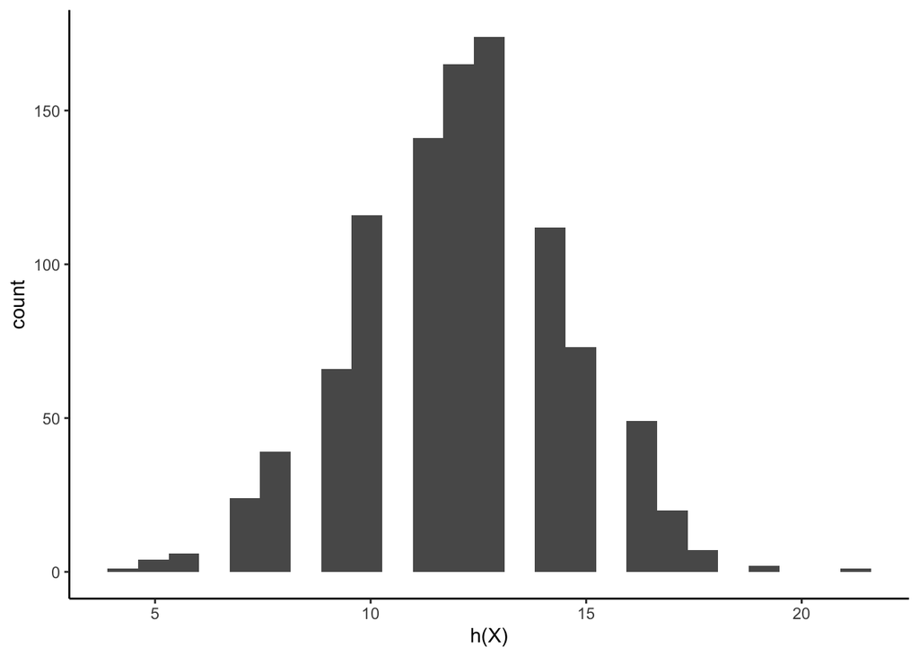

```r
set.seed(12345)
vertices<-1:16

#the edges tibble contains all the plot adjacencies in the 4x4 lattice
i <- c(1, 1, 2, 2, 2, 3, 3, 3, 4, 4, 5, 5, 5, 6, 6, 6, 6, 7, 7, 7, 7, 8, 8, 8, 9, 9, 9, 10, 10, 10, 10, 11, 11, 11, 11, 12, 12, 12, 13, 13, 14, 14, 14, 15, 15, 15, 16, 16)
j <- c(2, 5, 1, 3, 6, 2, 4, 7, 3, 8, 1, 6, 9, 2, 5, 7, 10, 3, 6, 8, 11, 4, 7, 12, 5, 10, 13, 6, 9, 11, 14, 7, 10, 12, 15, 8, 11, 16, 9, 14, 10, 13, 15, 11, 14, 16, 12, 15)
edges <- tibble(
i = i,
j= j ) %>%
filter(i < j)

#h calculates the number of adjacent plots with the same label
h <- function(x, edges) {sum(x[edges$i] == x[edges$j])}

#AR for this ising model
ar_ising <- function(vertices, edges, beta) {a <- FALSE
  n <- length(vertices)
  m <- nrow(edges)
  while (!a) {
    x <- (rbinom(length(vertices), 1, 0.5))
    u <- runif(1)
    a <- (u < exp(beta * (h(x, edges)-nrow(edges))))
  }
return(x) }

#to solve problem a
res<-replicate(1000, h(ar_ising(vertices=vertices, edges=edges, beta=0), edges=edges))

ggplot(data=NULL)+geom_histogram(aes(x=res), bins=25)+theme_classic()+xlab("h(X)")
```

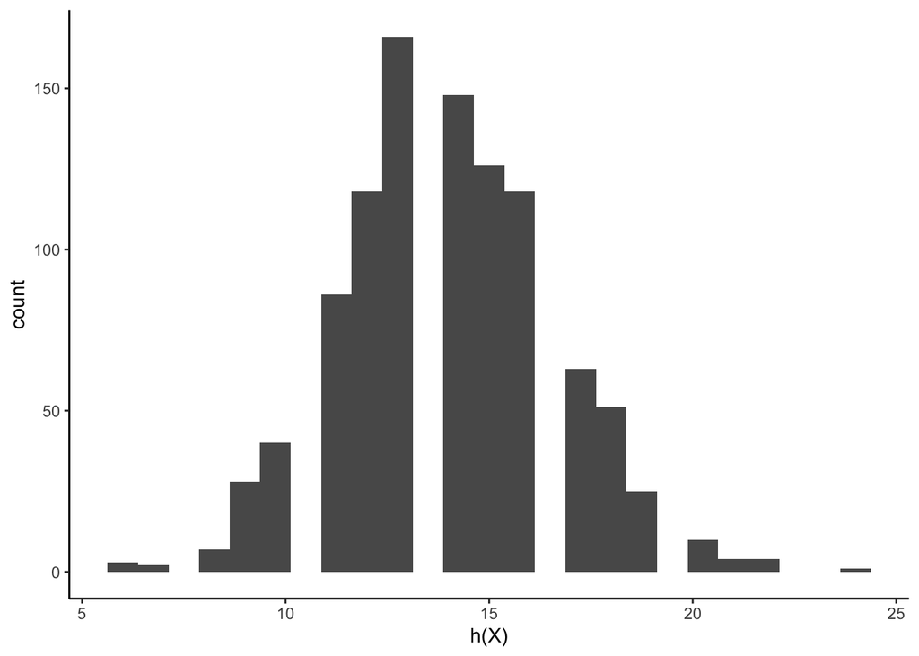

```r
set.seed(12345)
res<-replicate(1000, h(ar_ising(vertices=vertices, edges=edges, beta=0.3), edges=edges))

ggplot(data=NULL)+geom_histogram(aes(x=res), bins=25)+theme_classic()+xlab("h(X)")
```

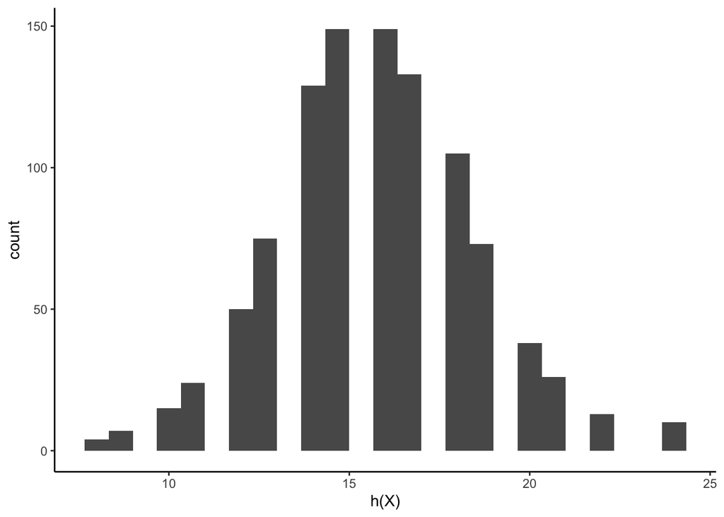

```r
set.seed(12345)
res<-replicate(1000, h(ar_ising(vertices=vertices, edges=edges, beta=0.6), edges=edges))

ggplot(data=NULL)+geom_histogram(aes(x=res), bins=25)+theme_classic()+xlab("h(X)")
```

Suppose our goal is to sample from the unnormalized density:
$$f(x_1, x_2, x_3, x_4) = \left[\sum_{i = 1}^4 i x_i\right] \mathbb{I}((x_1, \ldots, x_4) \in [0, 1]^4).$$

1. What is $\max_{(x_1, \ldots, x_4) \in [0, 1]^4} f(x_1, \ldots, x_4)$?
2. Write code to generate samples from $f$ using AR. Use this to estimate $\mathbb{E}[X_1 + \cdots + X_4]$ with 1000 samples. Report your answer as $a \pm b$.
1. $f(x_1, \ldots, x_4)$ is maximized when all the $x_i$ are maximized because $f$ is a monotonically increasing function wrt $x_1 \ldots x_4$. $x_i \in [0,1]$ are all maximized at $x_i=1$. Therefore: $\max_{(x_1, \ldots, x_4) \in [0, 1]^4} f(x_1, \ldots, x_4)=f(x_1=1, x_2=1, x_3=1, x_4=1)=1+2+3+4=\boxed{10}$

```r
set.seed(12345)
ar_fun<-function(){
  a<-FALSE
  while(!a){
    #step 1: draw 4 random uniform variables (X1, ... , X4)
    x<-runif(4, 0, 1)
    #step 2: draw U uniformly from [0,1]
    u<-runif(1, 0, 1)
    #step 3: if U \leq f(x)/g(x) where g(x) is max value, return X
    a<-(u <= (1*x[1]+2*x[2]+3*x[3]+4*x[4])/10)
  }
  return(x)
}

res<-replicate(1000, ar_fun())

tibble(
  est_mean=mean(apply(res, MARGIN=2, FUN=sum)),
  est_sd=sd(apply(res, MARGIN=2, FUN=sum))/sqrt(dim(res)[2])
)
```

```
## # A tibble: 1 x 2
##   est_mean est_sd
##      <dbl>  <dbl>
## 1     2.19 0.0172
```

My AR estimate for $\mathbb{E}[X_1 + \cdots + X_4]=\boxed{2.190 \pm 0.018}$.

Suppose our goal is to sample from the unnormalized density:
$$f(x_1, x_2, x_3, x_4) = 1 + \left[\sum_{i = 1}^4 x_i\right] \mathbb{I}((x_1, \ldots, x_4) \in \{0, 1\}^4).$$

Construct an AR algorithm with draws that are uniform over $\{0, 1\}^4$ to draw $(X_1, \ldots, X_4) \sim f$. Using 1000 of your draws, estimate $\mathbb{E}[X_1]$. Report your answer as $a \pm b$.

Note that the maximum of $f$ is 5. We use this fact to design our AR algorithm.

```r
set.seed(12345)

ar_p6<-function(){
  a<-FALSE
  while(!a){
    #step 1: draw 4 random uniform variables (X1, ... , X4)
    x<-runif(4, 0, 1)
    #step 2: draw U uniformly from [0,1]
    u<-runif(1, 0, 1)
    #step 3: if U \leq f(x)/g(x) where g(x) is max value, return X
    a<-(u <= (1+sum(x))/5)
  }
  return(x)
}

res<-replicate(1000, ar_p6())

tibble(
  est_mean=mean(res[1,]),
  est_sd=sd(res[1,])/sqrt(dim(res)[2])
)
```

```
## # A tibble: 1 x 2
##   est_mean  est_sd
##      <dbl>   <dbl>
## 1    0.545 0.00909
```

My AR estimate for $\mathbb{E}[X_1]=\boxed{0.5450 \pm 0.0091}$

Consider the Ising model on the graph $G$ that consists of two nodes connected by an edge:

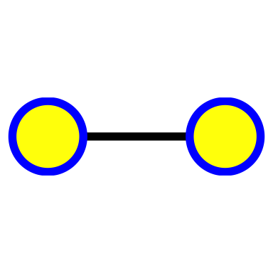

Then the state space of configurations is $\Omega = \{(0, 0), (0, 1), (1, 0), (1, 1)\}$. Note that
$$h(0, 0) = h(1, 1) = 1, \ h(1, 0) = h(0, 1) = 0,$$
so the unnormalized density is
$$g(0, 0) = g(1, 1) = \exp(\beta), \ g(1, 0) = g(0, 1) = 1.$$
Adding these up gives the normalizing constant $Z(\beta)$ for this graph, which is
$$2 + 2 \exp(\beta).$$

Note that for the 2 by 2 lattice there are $2^4 = 16$ configurations.

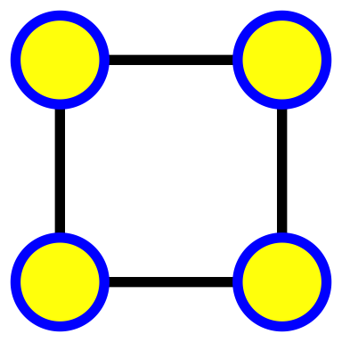

Find $Z(\beta)$ for the 2 by 2 lattice.

Let’s list out all possible configurations on the 2x2 lattice and their corresponding h values:

$$h(0,0,0,0)=h(1,1,1,1)=4 \\
h(1,1,1,0)=h(1,1,0,1)=h(1,0,1,1)=h(0,1,1,1)=h(0,0,0,1)=h(0,0,1,0)= \\
\\h(0,1,0,0)=h(1,0,0,0)=h(1,1,0,0)=h(1,0,0,1)=h(0,0,1,1)=h(0,1,1,0)=2 \\
h(1,0,1,0)=h(0,1,0,1)=0$$

The unnormalized density of the first set of terms is $g=\exp{(4\beta)}$. The unnormalized density for the second set of terms is $g=\exp{(2\beta)}$. The unnormalized density for the third set of terms is $g=1$.

Consider a draw $X = (X_1, \ldots, X_4)$ uniform from $\{0, 1\}^4$.

1. What is the density of $X$ with respect to counting measure?
2. Find an importance sampling function $g$ such that
   $$\mathbb{E}[g(X)] = \sum_{(x_1, \ldots, x_4) \in \{0, 1\}^4} \exp(\beta h(x)).$$
3. Use $g$ with 1000 samples to estimate $Z(1.5)$. Report your answer as $a \pm b$.
1. What is density of $X$ with respect to counting measure? $X$ has density wrt counting measure if $X$ is discrete and $f_X(i)=P(X=i)$. For $i \in \{0,1\}^4$, $P(X=i)=1/16$. Therefore, $f_X(i)=\boxed{\frac{1}{16} \mathbb{I}(i \in \{0,1\}^4)}$.
2. Find the importance sampling function $g(X)$ to satisfy requirement. Recall that the importance sampling function is defined as $g(x)=\frac{f(x)}{f_X(x)}$ and $\mathbb{E}[g(X)]=\sum f(x) dx$ (when working in discrete case). Thus, the importance sampling function that we’re looking for is $g(x)=\frac{f(x)}{f_X(x)}=\frac{\exp{(\beta h(x))}}{1/16} \mathbb{I}(i \in \{0,1\}^4)= \boxed{16 \exp{(\beta h(x))} \mathbb{I}(i \in \{0,1\}^4)}$.
3. We know that $Z(\beta)=\sum \exp{(\beta h(x))}$ from lecture notes. To importance sample and estimate $Z(\beta)$, I will repeatedly draw values from $g(x)$ and calculate their mean.

```r
set.seed(12345)
#helper function h(x)
h <- function(x, edges) {sum(x[edges$i] == x[edges$j])}

#edges on 2x2 lattice
i <- c(1, 1, 2, 2, 3, 3, 4, 4)
j <- c(2, 4, 1, 3, 2, 4, 1, 3)
edges <- tibble(
i = i,
j= j ) %>%
filter(i < j)

gofx_samp<-function(beta){
  x<-sample(c(0,1), size=4, replace=TRUE)
  h<-h(x, edges)
  return(16*exp(beta*h))
}

res<-replicate(1000, gofx_samp(beta=1.5))
tibble(
  est_mean=mean(res),
  est_sd=sd(res)/sqrt(length(res))
)
```

```
## # A tibble: 1 x 2
##   est_mean est_sd
##      <dbl>  <dbl>
## 1    1087.   66.0
```

Thus, my estimate is $\boxed{1087 \pm 66}$.

The density of a *standard Cauchy random variable* is
$$f(x) = \frac{2}{\tau} \cdot \frac{1}{1 + x^2}.$$
The ITM of generating a standard Cauchy using a standard uniform is to use
$$\tan((\tau / 2)(2U - 1))$$
Essentially this generates an angle uniformly between $-90^\circ$ and $90^\circ$, and then takes the tangent of it.

1. Write R code that uses draws from to generate from $[0, 1] \times [-1, 1]$ together with AR to draw uniformly from the right side of the unit circle:
   $$\{(x, y) : x \geq 0, x^2 + y^2 \leq 1\}.$$
2. Given such a sample $(X, Y)$, then use $Y / X$ to output samples from the standard Cauchy distribution. Repeat 1000 times to get an estimate of $\mathbb{P}(|T| \geq 1)$ for $T$ a standard Cauchy. Report your answer as $a \pm b$.

```r
#this function samples from the right side of the unit circle
samp_unit_circ<-function(){
  a<-FALSE
  while(!a){
    #step 1: draw 4 random uniform variables (X1, ... , X4)
    x<-c(runif(1, 0, 1), runif(1, -1, 1))
    #step 2: if inside unit circle return
    a<-(sum(x^2)<=1)
  }
  return(x)
}
```

2. By sampling $(X,Y)$ uniformly over the unit circle, $Y/X$ will give us our Cauchy RVs.

```r
set.seed(12345)

xy_pairs<-replicate(1000, samp_unit_circ())

cauchy_rvs<-xy_pairs[2,]/xy_pairs[1,]

tibble(
  est_prob=sum(cauchy_rvs>=1)/length(cauchy_rvs),
  est_sd=sd(cauchy_rvs>=1)/sqrt(length(cauchy_rvs))
)
```

```
## # A tibble: 1 x 2
##   est_prob est_sd
##      <dbl>  <dbl>
## 1    0.252 0.0137
```

1. Use uniformly generated permutations on 10 elements together with AR to write R code to uniformly generate from permutations such that the value in the first position is larger than the number in the fourth position. So $(4, 7, 3, 2, 10, 9, 6, 8, 1)$ would be valid but $(2, 7, 3, 4, 10, 9, 6, 8, 1)$ would not.
2. For the output permutations $(X_1, \ldots, X_{10})$, estimate $\mathbb{E}[X_4]$ using Basic Monte Carlo and 1000 samples. Report your result as $a \pm b$.

```r
ar_perm<-function(){
  a<-FALSE
  while(!a){
    samp<-sample(1:10, replace=FALSE)
    a<-(samp[1]>samp[4])
  }
  return(samp)
}
```

```r
set.seed(12345)
x4s<-replicate(1000, ar_perm()[4])
tibble(
  est_mean=mean(x4s),
  est_sd=sd(x4s)/sqrt(length(x4s))
)
```

```
## # A tibble: 1 x 2
##   est_mean est_sd
##      <dbl>  <dbl>
## 1     3.78 0.0706
```

My basic MC estimate for $\mathbb{E}[X_4]$ is $\boxed{3.780 \pm 0.071}$.